# Real Estate Prices Prediction and Logistic Regression on Marketing Dataset

Francesco Esposito, Claudio Raffaele Salerno, Davide Gaito

2024-05-21

# ANALISI DI REGRESSIONE MULTIPLA

```r
# Eseguire dal progetto o utilizzare scripts/render.R.
# Il file analysis.Rmd si trova nella radice del repository.
stopifnot(file.exists("data/house_prices.csv"),
          file.exists("data/bank_marketing.csv"))
```

# Introduzione

Il dataset didattico è descritto nel progetto originale come relativo ai prezzi delle case negli Stati Uniti; la fonte primaria non è indicata nei file forniti; si compone di 4548 osservazioni e 6 variabili. Controlliamo rapidamente le variabili presenti:

- **Avg. Area Income** : dati numerici relativi alla zona media di reddito in cui è ubicata la casa in unità di $;
- **HouseAge** : età della casa espressa in anni;
- **Number of Rooms**: numero di stanze/vani;
- **Number of Bedrooms** : numero di camere da letto;
- **AreaPopulation** : popolazione unitaria della zona in cui si trova la casa;
- **Price** : prezzo degli immobili in unità di $.

# EDA

Carichiamo le librerie:

```r
library(readr)    #lettura dati
library(corrplot) #visualizzazione  matrice di correlazione
library(ggplot2)  #migliore visualizzazione  dei grafici
library(cowplot)  #collegato a ggplot2, fornisce grafici migliori
library(lmtest)   #test del modello di regressione lineare
library(car)      #QQplot
library(sandwich) #analisi di regressione con stime robuste
library(GGally)   #grafici più accurati
library(pscl)     #per McFadden R^2
library(caret)    #ConfusionMatrix
library(ROCR)     #funzione di previsione per calcolare ROC e AUC
library(dplyr)    #accorpare livelli variabili categoriche
```

Carichiamo i Dati:

```r
house <- read_csv("data/house_prices.csv", show_col_types = FALSE)
if (interactive()) View(house)
```

Controllo la struttura dei dati e la corretta natura delle variabili:

```r
str(house)
```

```
## spc_tbl_ [4,548 × 6] (S3: spec_tbl_df/tbl_df/tbl/data.frame)
##  $ Avg. Area Income  : num [1:4548] 79545 79249 61287 63345 59982 ...
##  $ House Age         : num [1:4548] 5.68 6 5.87 7.19 5.04 ...
##  $ Number of Rooms   : num [1:4548] 7.01 6.73 8.51 5.59 7.84 ...
##  $ Number of Bedrooms: num [1:4548] 4.09 3.09 5.13 3.26 4.23 4.04 3.41 2.42 2.3 6.1 ...
##  $ Area Population   : num [1:4548] 23087 40173 36882 34310 26354 ...
##  $ Price             : num [1:4548] 1059034 1505891 1058988 1260617 630943 ...
##  - attr(*, "spec")=
##   .. cols(
##   ..   `Avg. Area Income` = col_double(),
##   ..   `House Age` = col_double(),
##   ..   `Number of Rooms` = col_double(),
##   ..   `Number of Bedrooms` = col_double(),
##   ..   `Area Population` = col_double(),
##   ..   Price = col_double()
##   .. )
##  - attr(*, "problems")=<externalptr>
```

```r
head(house)
```

```
## # A tibble: 6 × 6
##   `Avg. Area Income` `House Age` `Number of Rooms` `Number of Bedrooms`
##                <dbl>       <dbl>             <dbl>                <dbl>
## 1             79545.        5.68              7.01                 4.09
## 2             79249.        6.00              6.73                 3.09
## 3             61287.        5.87              8.51                 5.13
## 4             63345.        7.19              5.59                 3.26
## 5             59982.        5.04              7.84                 4.23
## 6             80176.        4.99              6.10                 4.04
## # ℹ 2 more variables: `Area Population` <dbl>, Price <dbl>
```

Controllo le statistiche descrittive:

```r
summary(house)
```

```
##  Avg. Area Income   House Age     Number of Rooms  Number of Bedrooms
##  Min.   : 17797   Min.   :2.644   Min.   : 3.236   Min.   :2.000
##  1st Qu.: 61485   1st Qu.:5.332   1st Qu.: 6.300   1st Qu.:3.140
##  Median : 68817   Median :5.961   Median : 7.002   Median :4.050
##  Mean   : 68612   Mean   :5.979   Mean   : 6.988   Mean   :3.982
##  3rd Qu.: 75821   3rd Qu.:6.658   3rd Qu.: 7.666   3rd Qu.:4.490
##  Max.   :107702   Max.   :9.519   Max.   :10.760   Max.   :6.500
##  Area Population       Price
##  Min.   :  172.6   Min.   :  15939
##  1st Qu.:29423.2   1st Qu.: 997775
##  Median :36215.6   Median :1234571
##  Mean   :36187.5   Mean   :1233916
##  3rd Qu.:42880.6   3rd Qu.:1470616
##  Max.   :69592.0   Max.   :2469066
```

Verifico se ci sono valori mancanti:

```r
cat("Ci sono valori mancanti?" , any(is.na(house)))
```

```
## Ci sono valori mancanti? FALSE
```

Rinominiamo le variabili al fine di rendere più snella la procedura di coding:

```r
income=house$`Avg. Area Income`
age=house$`House Age`
n.rooms=house$`Number of Rooms`
n.bedrooms=house$`Number of Bedrooms`
area.population=house$`Area Population`
price=house$Price
```

Vediamo come sono distribuite graficamente le variabili oggetto di analisi:

*Distribuzioni di densità*:

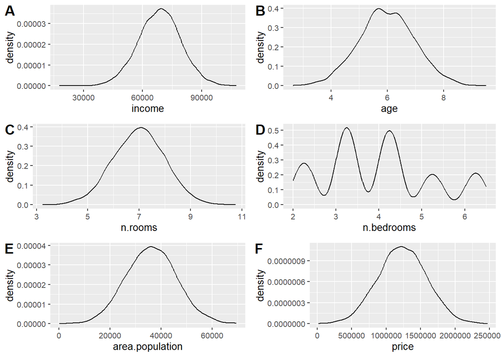

```r
kernel.income=ggplot(house, aes(x=income)) + geom_density() +
theme_gray(base_size = 10)

kernel.age=ggplot(house, aes(x=age)) + geom_density() +
theme_gray(base_size = 10)

kernel.n.rooms=ggplot(house, aes(x=n.rooms)) + geom_density() +
theme_gray(base_size = 10)

kernel.n.bedrooms=ggplot(house, aes(x=n.bedrooms)) + geom_density() +
theme_gray(base_size = 10)

kernel.area.population=ggplot(house, aes(x=area.population)) +
geom_density() + theme_gray(base_size = 10)

kernel.price=ggplot(house, aes(x=price)) + geom_density() +
theme_gray(base_size = 10)

plot_grid(kernel.income, kernel.age, kernel.n.rooms, kernel.n.bedrooms,
      kernel.area.population, kernel.price, labels="AUTO", nrow = 3, ncol = 2)
```

*Boxplot*:

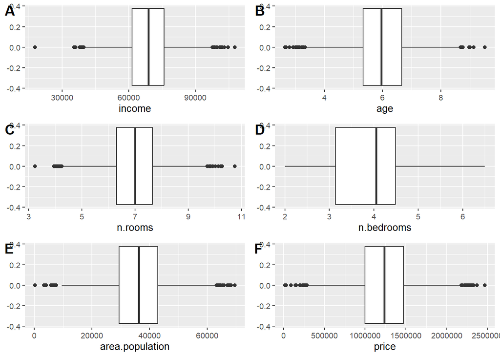

```r
box.income=ggplot(house, aes(x=income)) + geom_boxplot() +
  theme_gray(base_size = 10)

box.age=ggplot(house, aes(x=age)) + geom_boxplot() +
  theme_gray(base_size = 10)

box.n.rooms=ggplot(house, aes(x=n.rooms)) + geom_boxplot() +
  theme_gray(base_size = 10)

box.n.bedrooms=ggplot(house, aes(x=n.bedrooms))+ geom_boxplot() +
  theme_gray(base_size= 10)

box.n.bedrooms=ggplot(house, aes(x=n.bedrooms))+ geom_boxplot() +
  theme_gray(base_size= 10)

box.area.population=ggplot(house, aes(x=area.population))+ geom_boxplot() +
  theme_gray(base_size= 10)

box.price=ggplot(house, aes(x=price))+ geom_boxplot() +
  theme_gray(base_size= 10)

plot_grid(box.income, box.age, box.n.rooms, box.n.bedrooms, box.area.population,
          box.price, labels="AUTO", nrow = 3, ncol = 2)
```

La visualizzazione dei boxplot delle variabili del dataset ci permette di ottenere una panoramica iniziale della distribuzione dei dati e di identificare eventuali anomalie o valori anomali (outliers).

Ora rileviamo la correlazione tra le variabili:

```r
cor(house)
```

```
##                    Avg. Area Income    House Age Number of Rooms
## Avg. Area Income        1.000000000 -0.010143260    -0.006591518
## House Age              -0.010143260  1.000000000     0.002683159
## Number of Rooms        -0.006591518  0.002683159     1.000000000
## Number of Bedrooms      0.024653775  0.017728397     0.464564938
## Area Population        -0.007291989 -0.014899518    -0.003877480
## Price                   0.641381623  0.450133626     0.341572876
##                    Number of Bedrooms Area Population     Price
## Avg. Area Income           0.02465378    -0.007291989 0.6413816
## House Age                  0.01772840    -0.014899518 0.4501336
## Number of Rooms            0.46456494    -0.003877480 0.3415729
## Number of Bedrooms         1.00000000    -0.018172432 0.1813707
## Area Population           -0.01817243     1.000000000 0.4114532
## Price                      0.18137070     0.411453184 1.0000000
```

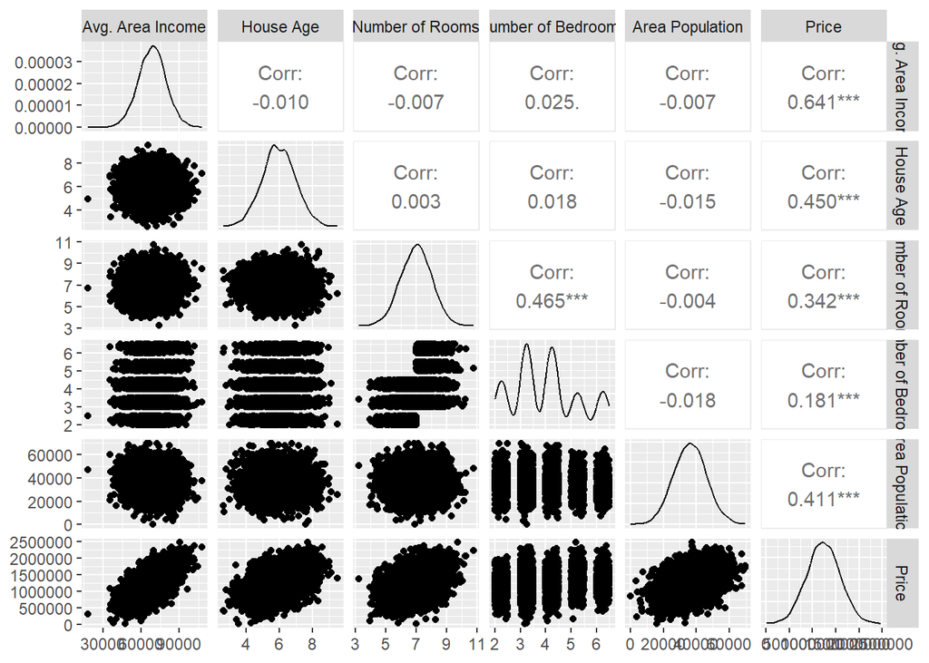

```r
ggpairs(as.data.frame(house))
```

Innanzitutto, abbiamo utilizzato il comando GGpairs per ottenere:

- **visualizzazione distribuzione variabili**: in modo tale che le diagonali mostrino le densità delle singole variabili al fine di avere un’idea della loro distribuzione;
- **esaminazione delle relazione tra le variabili**: gli scatter plots mostrano le relazione bivariate tra ogni coppia di variabili; mentre le correlazioni mostrano i coefficienti di correlazione tra le variabili per comprendere forza e direzione della loro relazione lineare;
- **identificazione di pattern e anomalie**: al fine di ottenere una identificazione più chiara di tendenze o outliers, che possono essere importanti per l’analisi dei dati;

Per quanto riguarda la correlazione tra variabile dipendente e quelle indipendenti, si evince che:

- rispetto a **Avg.Area.Income**: presenta un coefficiente di correlazione pari a 0.641. La forte correlazione positiva suggerisce che il reddito medio dell’area è un preditorre significativo del prezzo delle case;
- rispetto a **House Age**: presenta coefficiente di correlazione pari a 0.450. Vi è una moderata correlazione positiva, ciò indica che all’aumentare dell’età delle case si hanno prezzi più elevati. Una nostra considerazione, non conoscendo di preciso il luogo di rilevazione delle osservazioni, è che potrebbe trattarsi di case considerate di rilievo storico e quindi avere un valore aggiunto per la loro età e/o carattere distintivo; o, ancora, di case situate vicino ai principali servizi funzionali al benessere psico-fisico dell’acquirente;
- rispetto a **Number of Rooms**: presenta coeffciente di correlazione pari a 0.342. Per cui, vi è moderata correlazione positiva, ciò indica che case con più stanze presentano un prezzo più elevato;
- rispetto a **Number of Bedrooms**: presenta coefficiente di correlazione pari a 0.181. Vi è debole correlazione positiva, ciò suggerisce che il numero di camere da letto ha un’influenza minore sul prezzo delle case rispetto alle altre variabili;
- rispetto a **Area Population**: presenta coefficiente di correlazione pari a 0.411. Vi è, quindi, moderata correlazione positiva, il che suggerisce che una più alta popolazione nell’area è associata a prezzi delle case più elevate.

Mentre, analizzando la relazione tra le variabili indipendenti, notiamo che:

- Le variabili “Number of Rooms” e “Number of Bedrooms” hanno una correlazione positiva moderata (0.46). Questo è logico poiché le case con più stanze tendono ad avere anche più camere da letto.
- La variabile “Avg. Area Income” non mostra correlazioni significative con altre variabili indipendenti, suggerendo che è una variabile relativamente indipendente.

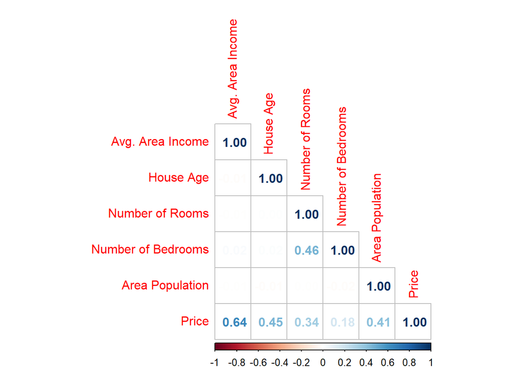

```r
corrplot(cor(house), method="number", type="lower")
```

La matrice di correlazione conferma quanto analizzato in precedenza con GGpairs.

# Analisi di regressione multipla

Ora passiamo all’implementazione di un modello di analisi di regressione multipla, il quale ha come variabile dipendente il prezzo, al fine di verificare la possibile influenza delle variabili indipendenti su di esso.

Per prima cosa dividiamo il dataset in Training Set, pari al 70% delle osservazioni e Testing Set, pari al restante 30% delle osservazioni.

```r
set.seed(500)
sample=sample(c(TRUE, FALSE), nrow(house), replace=TRUE, prob=c(0.7,0.3))
train=house[sample, ]
test=house[!sample, ]
```

successivamente, stimiamo il modello:

```r
stima1 <- lm(formula = Price ~ ., data = train)
summary(stima1)
```

```
##
## Call:
## lm(formula = Price ~ ., data = train)
##
## Residuals:
##     Min      1Q  Median      3Q     Max
## -340548  -71353   -1352   70111  322591
##
## Coefficients:
##                           Estimate    Std. Error  t value            Pr(>|t|)
## (Intercept)          -2642816.7444    21696.1418 -121.810 <0.0000000000000002
## `Avg. Area Income`         21.6760        0.1685  128.647 <0.0000000000000002
## `House Age`            166301.6227     1846.6097   90.058 <0.0000000000000002
## `Number of Rooms`      121752.6219     2068.5705   58.858 <0.0000000000000002
## `Number of Bedrooms`     -686.0873     1661.2308   -0.413                0.68
## `Area Population`          15.1172        0.1840   82.143 <0.0000000000000002
##
## (Intercept)          ***
## `Avg. Area Income`   ***
## `House Age`          ***
## `Number of Rooms`    ***
## `Number of Bedrooms`
## `Area Population`    ***
## ---
## Signif. codes:  0 '***' 0.001 '**' 0.01 '*' 0.05 '.' 0.1 ' ' 1
##
## Residual standard error: 102200 on 3172 degrees of freedom
## Multiple R-squared:  0.9177, Adjusted R-squared:  0.9175
## F-statistic:  7069 on 5 and 3172 DF,  p-value: < 0.00000000000000022
```

Dal summary, osserviamo che:

- L’intercetta è altamente significativa e rappresenta il valore atteso del prezzo delle case quando tutte le variabili indipendenti sono uguali a zero. Questo valore non ha un’interpretazione pratica diretta poiché alcune variabili come il reddito medio dell’area e la popolazione dell’area non possono realisticamente essere zero;
- Un aumento di una unità nel reddito medio dell’area è associato a un aumento di 21.68 unità nel prezzo delle case, ceteris paribus. Questa variabile è altamente significativa;
- Un anno in più nell’età della casa è associato a un aumento di 166,300 unità nel prezzo delle case, ceteris paribus. Questa variabile è altamente significativa;
- Una stanza in più è associata a un aumento di 121,800 unità nel prezzo delle case, ceteris paribus. Questa variabile è altamente significativa;
- il numero di camere da letto non è significativo, indicando che non ha un impatto statistico significativo sul prezzo delle case, ceteris paribus;
- Un’unità in più nella popolazione dell’area è associata a un aumento di 15.12 unità nel prezzo delle case, ceteris paribus. Questa variabile è altamente significativa;

i risultati confermano l’output della matrice di correlazione.

Il modello completo presenta un $R^2$ di 0.9177 e un $R^2$ corretto di 0.9175, calcolati sul Training set. L’errore standard residuo è 102154.02 dollari. Queste misure descrivono l’adattamento in campione e non sostituiscono una valutazione predittiva su osservazioni escluse dalla stima.

Poichè la variabile “Number of Bedrooms” non è significativa, procediamo con la sua rimozione dal modello e effettuiamo una nuova stima in questo senso:

```r
stima2 <- lm(formula = Price ~ `Avg. Area Income` + `House Age` +
               `Number of Rooms` + `Area Population`, data = train)
summary(stima2)
```

```
##
## Call:
## lm(formula = Price ~ `Avg. Area Income` + `House Age` + `Number of Rooms` +
##     `Area Population`, data = train)
##
## Residuals:
##     Min      1Q  Median      3Q     Max
## -339561  -71512   -1094   70437  321362
##
## Coefficients:
##                         Estimate    Std. Error t value            Pr(>|t|)
## (Intercept)        -2642590.7533    21686.4054 -121.86 <0.0000000000000002 ***
## `Avg. Area Income`       21.6734        0.1684  128.74 <0.0000000000000002 ***
## `House Age`          166283.7916     1845.8636   90.08 <0.0000000000000002 ***
## `Number of Rooms`    121354.8061     1830.3783   66.30 <0.0000000000000002 ***
## `Area Population`        15.1198        0.1839   82.22 <0.0000000000000002 ***
## ---
## Signif. codes:  0 '***' 0.001 '**' 0.01 '*' 0.05 '.' 0.1 ' ' 1
##
## Residual standard error: 102100 on 3173 degrees of freedom
## Multiple R-squared:  0.9176, Adjusted R-squared:  0.9175
## F-statistic:  8839 on 4 and 3173 DF,  p-value: < 0.00000000000000022
```

Ora tutti i coefficienti sono significativamente diversi da 0.

Successivamente analizziamo gli intervalli di confidenza, essi ci forniscono una gamma di valori entro cui ci aspettiamo che cadano i veri coefficienti della popolazione con un certo livello di confidenza (in questo caso, il 95%).

```r
confint(stima2,level=0.95)
```

```
##                             2.5 %         97.5 %
## (Intercept)        -2685111.54653 -2600069.96007
## `Avg. Area Income`       21.34334       22.00353
## `House Age`          162664.58495   169902.99830
## `Number of Rooms`    117765.96166   124943.65055
## `Area Population`        14.75918       15.48035
```

Gli intervalli di confidenza al 95% di tutti i coefficienti del modello ridotto, inclusa l’intercetta, escludono lo zero.

Gli intervalli di confidenza descrivono l’incertezza dei coefficienti sotto le assunzioni del modello. Da soli non dimostrano robustezza alla misspecificazione o validità causale.

```r
cov.m=vcov(stima2)
cov.m
```

```
##                      (Intercept) `Avg. Area Income`      `House Age`
## (Intercept)        470300177.459   -1974.6283281495 -20705474.217017
## `Avg. Area Income`     -1974.628       0.0283431260         5.502990
## `House Age`        -20705474.217       5.5029898603   3407212.307911
## `Number of Rooms`  -23166472.911      -2.1675830178    -24942.587953
## `Area Population`      -1252.292       0.0002538756         3.019139
##                    `Number of Rooms` `Area Population`
## (Intercept)        -23166472.9108883  -1252.2915651516
## `Avg. Area Income`        -2.1675830      0.0002538756
## `House Age`           -24942.5879526      3.0191391721
## `Number of Rooms`    3350284.5656685     -0.1668288623
## `Area Population`         -0.1668289      0.0338207454
```

# Analisi dei Residui

Calcoliamo valori stimati e residui e generiamo una tabella contenente questi ultimi per le prime 12 osservazioni del dataset;

```r
fitted_values = stima2$fitted.values
residual = stima2$residuals
head(cbind(train[,-1], fitted_values, residual), 12)
```

```
##    House Age Number of Rooms Number of Bedrooms Area Population     Price
## 1   7.188236        5.586729               3.26        34310.24 1260616.8
## 2   4.988408        6.104512               4.04        26748.43 1068138.1
## 3   6.025336        8.147760               3.41        60828.25 1502055.8
## 4   8.093513        5.042747               4.10        47224.36 1707045.7
## 5   6.919535        5.993188               2.27        32326.12 1291331.5
## 6   5.443156        8.517513               4.01        23929.52 1306674.7
## 7   5.067890        8.219771               3.12        39717.81 1556786.6
## 8   4.788550        5.097010               4.30        24595.90  528485.2
## 9   5.947165        7.187774               5.12        35719.65 1019425.9
## 10  5.739411        7.091808               5.49        44922.11 1030591.4
## 11  6.627457        8.011898               4.07        47560.78 2146925.3
## 12  4.210323        5.478088               4.31        40358.96  718887.2
##    fitted_values   residual
## 1      1122344.4  138272.44
## 2      1069826.3   -1688.19
## 3      1670041.4 -167985.53
## 4      1774518.7  -67473.01
## 5      1309789.0  -18457.47
## 6      1242119.5   64555.20
## 7      1525673.4   31113.24
## 8       486314.1   42171.19
## 9      1135110.6 -115684.70
## 10     1197218.0 -166626.56
## 11     2021146.8  125778.53
## 12      730261.7  -11374.49
```

Il modello sembra avere una buona precisione generale, con alcuni residui relativamente piccoli (come nelle osservazioni 2 e 12), ma ci sono anche alcune predizioni con residui più grandi (come nelle osservazioni 1, 3, 9 e 10). I residui negativi indicano che il modello ha sovrastimato il prezzo reale, mentre residui positivi indicano una sottostima. Alcuni di questi sono significativamente grandi, suggerendo che ci possono essere outliers.

Successivamente procediamo al plot dei residui per valutare la bontà di adattamento del modello; apportando, però, una modifica al fine di eliminare la notazione esponenziale sull’asse delle ordinate:

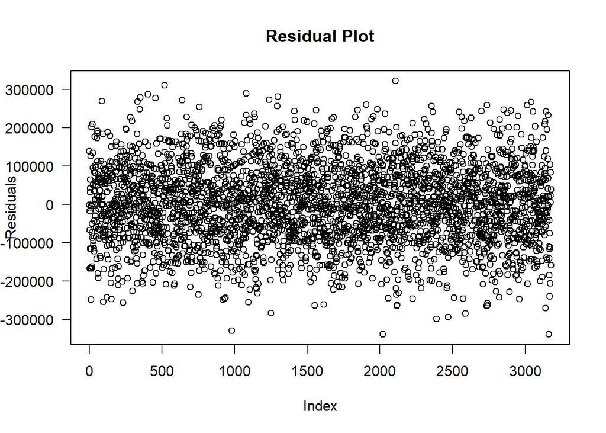

```r
# correzione notazione
plot(residual, ylab = "Residuals", xlab = "Index", main = "Residual Plot", axes = FALSE)
axis(1)
axis(2, at = pretty(residual), labels = format(pretty(residual), scientific = FALSE),
     las = 1)
box()
```

Il grafico dei residui suggerisce che il modello di regressione multipla è generalmente appropriato per i dati, infatti: i residui sono distribuiti intorno allo zero e non sembra esserci un pattern evidente in essi, il che è un buon segno e suggerisce che il modello non lascia sistematicamente fuori alcune componenti della variabilità dei dati. Di conseguenza, anche la varianza è abbastanza costante, infatti possiamo notare una dispersione uniforme sopra e sotto l’asse orizzontale: un primo indicatore di omoschedasticità.

Prima di passare alla verifica delle assunzioni di Gauss-Markov, calcoliamo:

```r
# i gradi di libertà
df=df.residual(stima2)
# varianza stimata
s.hat=t(residual)%*%residual/df
# errore standard residuo (RSE)
rse=sqrt(s.hat)
# residui standardizzati
sres=residual/rse
```

Successivamente andiamo a plottare la diagnostica del nostro modello:

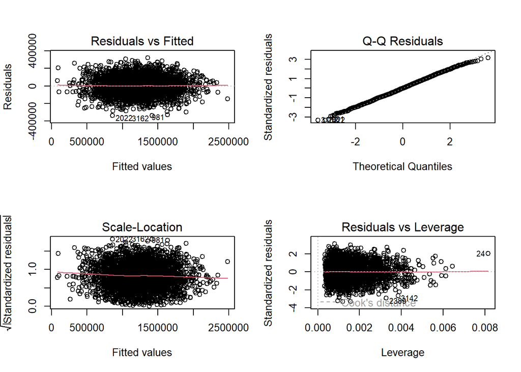

```r
par(mfrow=c(2,2))
plot(stima2)
```

- **Residual Vs Fitted Values**: il primo grafico, che mostra i residui sull’asse verticale e i valori stimati su quella orizzontale, suggerisce che i residui si distribuiscono casualmente intorno alla linea orizzontale a zero, ciò indica che il modello cattura correttamente la relazione tra la variabile dipendente e quelle indipendenti; inoltre, avendo una dispersione abbastanza uniforme lungo l’intervallo di valori stimati, suggerisce che l’ipotesi di omoschedasticità è rispettata;
- **Q-Q Plot**: confronta i quantili dei residui standardizzati con i quantili di una distribuzione normale. In questo caso, la maggior parte dei punti si allinea lungo la linea dell’intervallo di riferimento, ciò indica che i residui sono approssimativamente normali; le deviazioni alle code indica la presenza di una leggera non normalità dei residui a causa degli outliers;
- **Scale-Location**: questo grafico mostra la radice quadrata dei residui standardizzati rispetto ai valori stimati (fitted values). La linea rossa è orizzontale e la distribuzione dei punti è abbastanza uniforme lungo l’asse dei valori stimati. Questo indica che la varianza dei residui è costante (omoschedasticità), una delle assunzioni fondamentali della regressione lineare.
- **Residuals vs Leverage**: questo grafico mostra i residui standardizzati rispetto al leverage[^1], che misura l’influenza di ogni punto sull’adattamento del modello. Include anche le linee di Cook’s distance. Punti con alto leverage (a destra del grafico) indicano osservazioni che hanno un’influenza significativa sul modello. Mentre, punti al di fuori delle linee di Cook’s distance suggeriscono che queste osservazioni hanno un’influenza sproporzionata sulle stime dei parametri e dovrebbero essere esaminati attentamente;

Nel complesso, i grafici diagnostici suggeriscono che il modello di regressione multipla è generalmente appropriato per i dati, con residui che mostrano una distribuzione casuale e una varianza costante.

# Verifica dei punti influenti

Per verificare la presenza di punti influenti andremo a misurare la Cook’s distance e se essa è maggiore della soglia impostata, allora consideriamo il punto come influente:

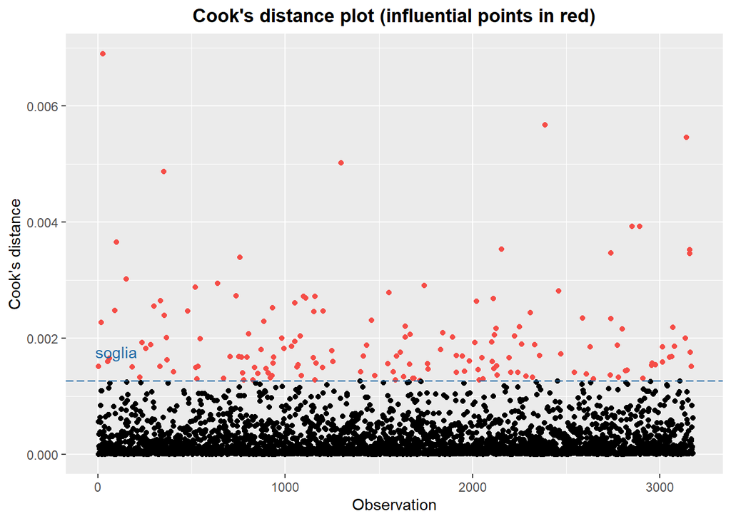

```r
# utilizziamo la soglia come criterio per determinare quali osservazione del dataset
# hanno un'influenza significativa sui parametri stimati del modello di regressione
# k è il numero di regressori, esclusa l'intercetta.
k <- length(coef(stima2)) - 1L
soglia <- 4 / (nrow(train) - k - 1L)
# Calcolo della distanza di Cook
cookd <- cooks.distance(stima2)
# Identificazione degli outliers
outliers <- which(cookd > soglia)
# Creazione di un indice per le osservazioni
index <- seq(1:length(stima2$residuals))
# Creazione del dataframe per il grafico
cookdf <- data.frame(cookd, index)
# Creazione del grafico con ggplot2
ggplot(cookdf, aes(x = index, y = cookd, color = cookd > soglia)) +
  geom_point() +
  scale_color_manual(values = c("black", "#F54D47")) +
  geom_hline(yintercept = soglia, linetype = "longdash", colour = "#1B68A6") +
  annotate("text", x = min(index) - 15, y = soglia + 0.0005,
           label = "soglia", colour = "#1B68A6", hjust = 0) +
  theme(legend.position = "none",
        plot.title = element_text(face = 'bold', hjust = 0.5)) +
  ggtitle("Cook's distance plot (influential points in red)") +
  labs(x = "Observation", y = "Cook's distance")
```

- i punti rossi sono le osservazioni che hanno una distanza di Cook superiore alla soglia. Questi sono potenzialmente influenti e possono avere un grande impatto sui coefficienti stimati del modello. Al contrario, i punti neri sono le osservazioni che hanno una distanza di Cook inferiore alla soglia e sono considerate non influenti;
- La maggior parte delle osservazioni ha una distanza di Cook relativamente bassa (vicina a zero), indicando che la questi non sono influenti in maniera sproporzionata sul modello. Al contempo, c’è un numero limitato di osservazioni che ha una distanza di Cook elevata, indicando che questi punti devono essere esaminati più da vicino per capire perché sono così influenti.
- La linea tratteggiata blu rappresenta una soglia comune per identificare le osservazioni influenti. Tipicamente, essa è fissata, per ragioni pratiche e convenzionali, a $\frac{4}{N-k-1}$. Le osservazioni che superano tale soglia possono indicare outliers o punti di dati che non sono ben spiegati dal modello.

Ora procediamo alla stima del modello, dopo l’eliminazione dei punti influenti:

```r
clean_data <- train[setdiff(seq_len(nrow(train)), outliers), , drop = FALSE]

reg_clean <- lm(sqrt(Price) ~ sqrt(`Avg. Area Income`) +
                sqrt(`House Age`) + sqrt(`Number of Rooms`) +
                sqrt(`Area Population`), data=clean_data)

summary(reg_clean)
```

```
##
## Call:
## lm(formula = sqrt(Price) ~ sqrt(`Avg. Area Income`) + sqrt(`House Age`) +
##     sqrt(`Number of Rooms`) + sqrt(`Area Population`), data = clean_data)
##
## Residuals:
##     Min      1Q  Median      3Q     Max
## -352.52  -30.19   -0.09   32.18  129.12
##
## Coefficients:
##                             Estimate  Std. Error t value            Pr(>|t|)
## (Intercept)              -2463.70668    20.21010 -121.91 <0.0000000000000002
## sqrt(`Avg. Area Income`)     5.26949     0.04176  126.19 <0.0000000000000002
## sqrt(`House Age`)          377.44717     4.18923   90.10 <0.0000000000000002
## sqrt(`Number of Rooms`)    296.32858     4.53468   65.35 <0.0000000000000002
## sqrt(`Area Population`)      2.57606     0.03193   80.69 <0.0000000000000002
##
## (Intercept)              ***
## sqrt(`Avg. Area Income`) ***
## sqrt(`House Age`)        ***
## sqrt(`Number of Rooms`)  ***
## sqrt(`Area Population`)  ***
## ---
## Signif. codes:  0 '***' 0.001 '**' 0.01 '*' 0.05 '.' 0.1 ' ' 1
##
## Residual standard error: 45.99 on 3012 degrees of freedom
## Multiple R-squared:  0.9193, Adjusted R-squared:  0.9192
## F-statistic:  8574 on 4 and 3012 DF,  p-value: < 0.00000000000000022
```

Questo modello è una verifica esplorativa di sensibilità: esclude i punti potenzialmente influenti individuati sul Training set e trasforma risposta e regressori con la radice quadrata. Il numero di righe usato nella stima è 3017, contro 3178 nel campione iniziale.

Poiché cambiano sia campione sia scala della risposta, il suo errore standard residuo e il suo $R^2$ non costituiscono un confronto diretto con il modello in dollari. Una soglia della distanza di Cook segnala osservazioni da esaminare; non dimostra che tali osservazioni siano errate.

## Valutazione predittiva sul Test set

Valutiamo il modello ridotto in livelli sul Test set separato prima della stima. Il modello trasformato resta un’analisi esplorativa e non entra in questa valutazione.

```r
house_pred <- predict(stima2, newdata = test)
house_error <- test$Price - house_pred
house_metrics <- data.frame(
  n_train = nrow(train),
  n_test = nrow(test),
  RMSE = sqrt(mean(house_error^2)),
  MAE = mean(abs(house_error)),
  R2_test = 1 - sum(house_error^2) / sum((test$Price - mean(test$Price))^2)
)
house_metrics
```

```
##   n_train n_test     RMSE      MAE  R2_test
## 1    3178   1370 98700.97 79196.78 0.921303
```

RMSE e MAE sono espressi in dollari; il $R^2$ del Test set utilizza la media dei prezzi nel Test set come riferimento descrittivo.

# Verifica delle assunzioni di Gauss-Markov

A.1) **Controllo grafico della specificazione**: il grafico Residuals Vs Fitted aiuta a individuare pattern nei residui, ma non dimostra da solo che la specificazione sia corretta o che i regressori siano esogeni.

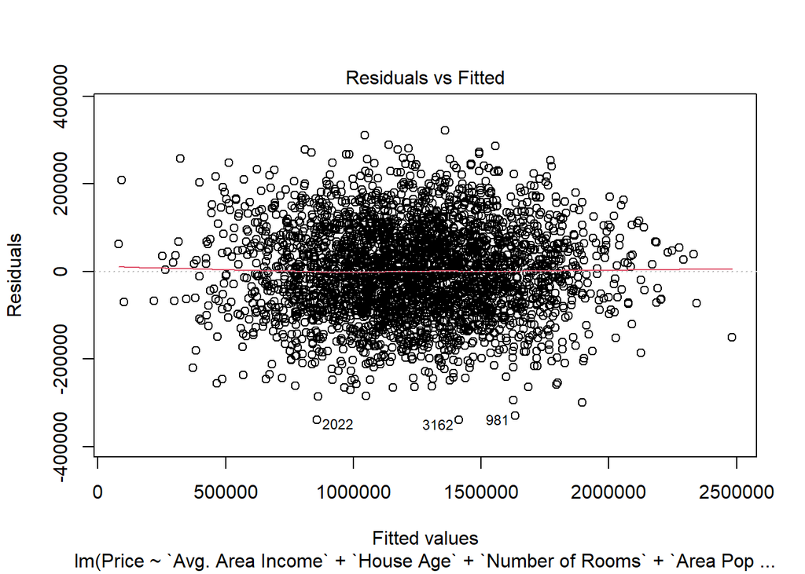

```r
plot(stima2, c(1))
```

A.2) **Media dei residui campionari uguale a 0**: $E(\epsilon_i) = 0,\forall i$__

```r
t.test(residual)
```

```
##
##  One Sample t-test
##
## data:  residual
## t = 0.00000000000000098385, df = 3177, p-value = 1
## alternative hypothesis: true mean is not equal to 0
## 95 percent confidence interval:
##  -3550.273  3550.273
## sample estimates:
##            mean of x
## 0.000000000001781468
```

In una regressione OLS con intercetta la somma dei residui è zero per costruzione, a meno di arrotondamenti numerici. Questo t-test non verifica l’ipotesi di esogeneità $E(\epsilon_i \mid X_i)=0$.

A.3) **Omoschedasticità**: $Var(\epsilon_i)=\sigma^2,\forall i$__

L’omoscedasticità implica che la varianza dei residui è costante per tutti i valori delle variabili indipendenti. Se questa ipotesi non è soddisfatta (cioè, se i residui mostrano eteroscedasticità), allora le inferenze statistiche basate sul modello di regressione potrebbero essere non affidabili.

In questo caso abbiamo verificato la presenza di omoschedasticità con due metodi:

- **Primo test: Breusch-Pagan Test**:

```r
bptest(stima2, data=train)
```

```
##
##  studentized Breusch-Pagan test
##
## data:  stima2
## BP = 5.2567, df = 4, p-value = 0.262
```

Il risultato suggerito dal p-value che in questo caso è pari a 0.262, quindi maggiore di 0.05, è che non ci sono prove sufficienti per rifiutare l’ipotesi nulla. Per cui non possiamo rifiutare l’ipotesi di omoscedasticità.

- **Secondo Test: White Test**:

```r
# Calcolo dei residui al quadrato
residual2 <- residual^2

# Creazione di un nuovo dataframe con i residui al quadrato
newhouse <- cbind(train, residual2)
head(newhouse)
```

```
##   Avg. Area Income House Age Number of Rooms Number of Bedrooms Area Population
## 1         63345.24  7.188236        5.586729               3.26        34310.24
## 2         80175.75  4.988408        6.104512               4.04        26748.43
## 3         64698.46  6.025336        8.147760               3.41        60828.25
## 4         80527.47  8.093513        5.042747               4.10        47224.36
## 5         73163.66  6.919535        5.993188               2.27        32326.12
## 6         73091.87  5.443156        8.517513               4.01        23929.52
##     Price   residual2
## 1 1260617 19119268451
## 2 1068138     2849985
## 3 1502056 28219139849
## 4 1707046  4552607468
## 5 1291332   340678259
## 6 1306675  4167374237
```

```r
# Assegnazione delle variabili indipendenti
i <- train$`Avg. Area Income`
H <- train$`House Age`
R <- train$`Number of Rooms`
A <- train$`Area Population`

# Modello ausiliario per il test di White
aux.reg <- lm(residual2 ~ i + H + R + A + I(i^2) + I(H^2) + I(R^2) + I(A^2)+
               i*H + i*R + i*A + H*R + H*A + R*A, newhouse)
summary(aux.reg)
```

```
##
## Call:
## lm(formula = residual2 ~ i + H + R + A + I(i^2) + I(H^2) + I(R^2) +
##     I(A^2) + i * H + i * R + i * A + H * R + H * A + R * A, data = newhouse)
##
## Residuals:
##          Min           1Q       Median           3Q          Max
## -13212129989  -9100731543  -5286822728   3490856723 106189362749
##
## Coefficients:
##                     Estimate       Std. Error t value Pr(>|t|)
## (Intercept) 14287902441.6252 24979052123.8968   0.572    0.567
## i               -173458.7736      307534.3171  -0.564    0.573
## H            2309670704.8740  3525804733.3910   0.655    0.512
## R             663874734.8579  3420674575.7098   0.194    0.846
## A               -264561.6792      320126.0813  -0.826    0.409
## I(i^2)                2.3895           1.4764   1.618    0.106
## I(H^2)       -143679601.5613   186404074.3481  -0.771    0.441
## I(R^2)       -103299592.5547   184022441.0629  -0.561    0.575
## I(A^2)               -0.7352           1.8418  -0.399    0.690
## i:H              -26443.7539       23652.9856  -1.118    0.264
## i:R               -2642.5476       22990.0563  -0.115    0.908
## i:A                  -0.3535           2.3745  -0.149    0.882
## H:R             9220429.8728   256998381.5953   0.036    0.971
## H:A               21392.8975       24937.0466   0.858    0.391
## R:A               27919.8743       25219.1185   1.107    0.268
##
## Residual standard error: 14050000000 on 3163 degrees of freedom
## Multiple R-squared:  0.003872,   Adjusted R-squared:  -0.0005368
## F-statistic: 0.8783 on 14 and 3163 DF,  p-value: 0.5826
```

```r
# Calcolo del valore R^2
R2 <- summary(aux.reg)$r.squared

# Numero di osservazioni
n <- nrow(newhouse)

# Statistica del test di White
stat.test <- n * R2

# Poiché la statistica del test è distribuita asintoticamente come una
# variabile casuale Chi-quadrato con k gradi di libertà, dove k = numero di
# coefficienti - 1,
# per calcolare il p-value e decidere sulla presenza di eteroschedasticità,
# dobbiamo implementare il comando pchisq()

# Calcolo dei gradi di libertà
df <- length(aux.reg$coefficients) - 1

# Calcolo del p-value del test di White
p_value <- pchisq(stat.test, df = df, lower.tail = FALSE)

# Visualizzazione del p-value
p_value
```

```
## [1] 0.5817443
```

Il risultato ottenuto dal modello di regressione ausiliario utilizzato per il White test mostra alcuni punti importanti da considerare:

- L’$R^{2}$ è estremamente basso (0.003872), indicando che il modello spiega una quantità molto piccola della variabilità nei residui al quadrato. Inoltre, l’Adjusted $R^{2}$ è negativo (-0.0005368), il che può avvenire quando l’$R^{2}$ del modello è molto basso ed ha troppi parametri rispetto alla quantità di dati disponibili;
- Osservando i p-value associati ai coefficienti, vediamo che nessuno dei termini è statisticamente significativo al livello di significatività comune (ad esempio, 0.05);
- Il p-value ottenuto è 0.5817, che è molto più alto del livello di significatività comune (ad esempio, 0.05). Pertanto, non possiamo rigettare l’ipotesi nulla di omoschedasticità (costanza della varianza dei residui). In altre parole, non ci sono prove sufficienti per affermare che esista eteroschedasticità nei residui del modello.

A.4) **No Autocorrelazione**: $Cov(\epsilon_i, \epsilon_l) = 0, \forall i \neq l$__

La verifica dell’autocorrelazione dei residui è particolarmente rilevante per i dati temporali (serie temporali). Nel progetto non è stato effettuato un test di dipendenza. La natura cross-sectional dei dati non garantisce indipendenza: dipendenze spaziali o tra gruppi richiederebbero informazioni aggiuntive.

A.5) **Assenza di multicollinearità**:

La multicollinearità si verifica quando due o più variabili indipendenti in un modello di regressione sono altamente correlate tra loro. Questo può causare problemi nella stima dei coefficienti del modello, rendendoli instabili e difficili da interpretare.

Per verificare l’assenza di multicollinearità, possiamo calcolare il Variance Inflation Factor (VIF) per ciascuna variabile indipendente:

```r
vif(stima2)
```

```
## `Avg. Area Income`        `House Age`  `Number of Rooms`  `Area Population`
##           1.000426           1.000443           1.000102           1.000144
```

un VIF vcino all’1 per tutte le variabili indipendenti indica che c’è assenza di multicollinearità.

A.6) **Normalità dei residui**: $\epsilon_i \sim N(0, \sigma^2), \forall i$__

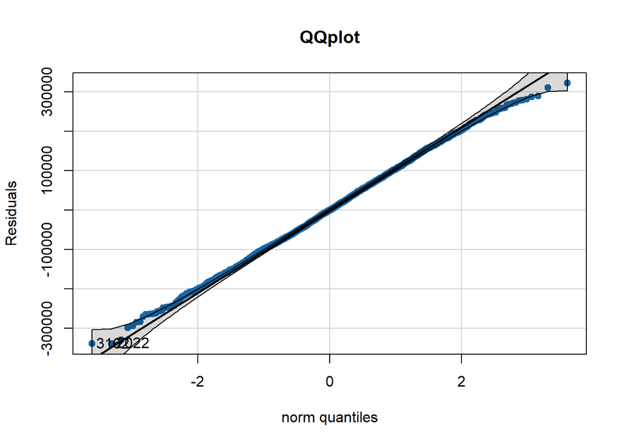

```
## [1] 3162 2022
```

```r
options(scipen = 999)
qqPlot(residuals(stima2), main = "QQplot", ylab = "Residuals",
       col.lines = "black", pch = 19, col = "#1B68A6")
```

L’allineamento nel Q-Q plot suggerisce una normalità approssimativa; non dimostra che gli errori abbiano una distribuzione esattamente normale. La normalità non è un’ipotesi del teorema di Gauss-Markov.

A conferma di quanto verificato sopra, compariamo la densità dei residui con la densità della distribuzione normale:

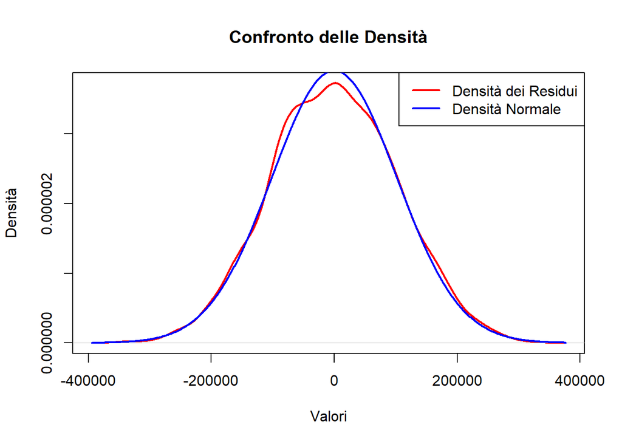

```r
# Calcolo della densità dei residui
density_residuals <- density(residual)

# Creazione di una distribuzione normale con la stessa media e deviazione standard
# dei residui
mean_residuals <- mean(residual)
sd_residuals <- sd(residual)
normal_density <- dnorm(density_residuals$x, mean = mean_residuals, sd = sd_residuals)

# Creazione del grafico
plot(density_residuals, main = "Confronto delle Densità", xlab = "Valori",
     ylab = "Densità", col = "red", lwd = 2)
lines(density_residuals$x, normal_density, col = "blue", lwd = 2)

# Aggiunta della legenda
legend("topright", legend = c("Densità dei Residui", "Densità Normale"),
       col = c("red", "blue"), lwd = 2)
```

# ANALISI DI REGRESSIONE LOGISTICA

> **Contesto di utilizzo.** La variabile `duration` è la durata della telefonata, quindi è disponibile a contatto concluso. Questo modello descrive/discrimina gli esiti dopo il contatto: non è un modello da usare per scegliere prima della chiamata quali clienti contattare. Per quel compito occorre escludere `duration` e ripetere la valutazione.

# Introduzione

Il dataset utilizzato per questa analisi rappresenta il risultato di una campagna di marketing effettuata da un istituo bancario portoghese e riporta il dettaglio degli utenti che hanno sottoscritto o meno un deposito a termine.

Il set di dati contiene 8 variabili con le seguenti informazioni:

*Informazioni sul cliente:*

- **age**: età del cliente (numerica);
- **balance**: bilancio annuale medio, in euro (numerica);

*Informazioni sull’ultimo contatto durante la campagna marketing*

- **day**: giorno dell’ultimo contatto (numerica);
- **duration**: durata dell’ultimo contatto, in secondi (numerica);

*Altri attributi:*

- **campaign**: numero di contatti avuti con il cliente durante la campagna (numerica);
- **pdays**: numero di giorni trascorsi da quando il cliente era stato contattato per una precedente campagna marketing (numerica);
- **previous**: numero di contatti avuti con il cliente prima dell’attuale campagna marketing (numerica);

*Variabile target:*

- **y**: il cliente ha sottoscritto un deposito a termine? (binaria).

Carichiamo i Dati:

```r
bank <- read.csv("data/bank_marketing.csv", sep=",")
if (interactive()) View(bank)
```

Controllo la struttura dei dati e la corretta natura delle variabili:

```r
str(bank)
```

```
## 'data.frame':    4521 obs. of  8 variables:
##  $ age     : int  30 33 35 30 59 35 36 39 41 43 ...
##  $ balance : int  1787 4789 1350 1476 0 747 307 147 221 -88 ...
##  $ day     : int  19 11 16 3 5 23 14 6 14 17 ...
##  $ duration: int  79 220 185 199 226 141 341 151 57 313 ...
##  $ campaign: int  1 1 1 4 1 2 1 2 2 1 ...
##  $ pdays   : int  -1 339 330 -1 -1 176 330 -1 -1 147 ...
##  $ previous: int  0 4 1 0 0 3 2 0 0 2 ...
##  $ y       : chr  "no" "no" "no" "no" ...
```

```r
head(bank)
```

```
##   age balance day duration campaign pdays previous  y
## 1  30    1787  19       79        1    -1        0 no
## 2  33    4789  11      220        1   339        4 no
## 3  35    1350  16      185        1   330        1 no
## 4  30    1476   3      199        4    -1        0 no
## 5  59       0   5      226        1    -1        0 no
## 6  35     747  23      141        2   176        3 no
```

Controllo le statistiche descrittive:

```r
summary(bank)
```

```
##       age           balance           day           duration
##  Min.   :19.00   Min.   :-3313   Min.   : 1.00   Min.   :   4
##  1st Qu.:33.00   1st Qu.:   69   1st Qu.: 9.00   1st Qu.: 104
##  Median :39.00   Median :  444   Median :16.00   Median : 185
##  Mean   :41.17   Mean   : 1423   Mean   :15.92   Mean   : 264
##  3rd Qu.:49.00   3rd Qu.: 1480   3rd Qu.:21.00   3rd Qu.: 329
##  Max.   :87.00   Max.   :71188   Max.   :31.00   Max.   :3025
##     campaign          pdays           previous            y
##  Min.   : 1.000   Min.   : -1.00   Min.   : 0.0000   Length:4521
##  1st Qu.: 1.000   1st Qu.: -1.00   1st Qu.: 0.0000   Class :character
##  Median : 2.000   Median : -1.00   Median : 0.0000   Mode  :character
##  Mean   : 2.794   Mean   : 39.77   Mean   : 0.5426
##  3rd Qu.: 3.000   3rd Qu.: -1.00   3rd Qu.: 0.0000
##  Max.   :50.000   Max.   :871.00   Max.   :25.0000
```

Verifico se ci sono valori mancanti:

```r
cat("Ci sono valori mancanti?" , any(is.na(bank)))
```

```
## Ci sono valori mancanti? FALSE
```

Da una prima panoramica sui dati, notiamo che ci sono: - 4521 osservazioni e 8 variabili; - 7 variabili numeriche; - 1 target; - Non ci sono valori mancanti.

Il nostro scopo è quello di implementare un modello di regressione logistica per predire se un utente sottoscriverà o meno un deposito.

Per prima cosa procedo a trasformare la mia y, che comprende yes - no, in fattore:

```r
y_bin <- ifelse(bank$y == "yes", 1, 0)
y_bin <- as.factor(y_bin)
summary(y_bin)
```

```
##    0    1
## 4000  521
```

Ora creiamo un grafico per avere una visualizzazione della variabile binaria y_bin:

```r
# Creiamo nuovo dataframe senza colonne duplicate
bank1 <- bank
bank1$y_bin <- y_bin

# Verifichiamo la struttura del dataframe per assicurarci che non ci siano colonne
# duplicate
str(bank1)
```

```
## 'data.frame':    4521 obs. of  9 variables:
##  $ age     : int  30 33 35 30 59 35 36 39 41 43 ...
##  $ balance : int  1787 4789 1350 1476 0 747 307 147 221 -88 ...
##  $ day     : int  19 11 16 3 5 23 14 6 14 17 ...
##  $ duration: int  79 220 185 199 226 141 341 151 57 313 ...
##  $ campaign: int  1 1 1 4 1 2 1 2 2 1 ...
##  $ pdays   : int  -1 339 330 -1 -1 176 330 -1 -1 147 ...
##  $ previous: int  0 4 1 0 0 3 2 0 0 2 ...
##  $ y       : chr  "no" "no" "no" "no" ...
##  $ y_bin   : Factor w/ 2 levels "0","1": 1 1 1 1 1 1 1 1 1 1 ...
```

```r
# Verifichiamo che la lunghezza di y_bin sia coerente con il dataframe bank1
print(length(bank1$y_bin))
```

```
## [1] 4521
```

```r
print(nrow(bank1))
```

```
## [1] 4521
```

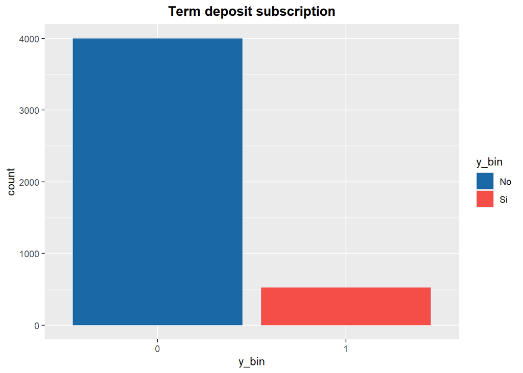

```r
# Creiamo il grafico a barre con ggplot2
ggplot(bank1, aes(x = y_bin, fill = y_bin)) +
  geom_bar() +
  scale_fill_manual(labels = c('No', 'Si'), values = c("#1B68A6", "#F54D47")) +
  theme(plot.title = element_text(face = 'bold', hjust = 0.5)) +
  ggtitle('Term deposit subscription')
```

Successivamente dividiamo il dataset in Training Set, pari al 70% delle osservazioni e Test Set, pari al restante 30% delle osservazioni:

```r
# Seed autonomo: lo split bancario non dipende dai chunk precedenti.
set.seed(501)
n <- nrow(bank1)
idx.est <- sample(1:n, floor(0.7 * n))
train.bank1 <- bank1[idx.est, ] # Training set
test.bank1 <- bank1[-idx.est, ] # Test set
```

ora andiamo a visualizzare la variabile y_bin sia nel Training set sia nel Test set:

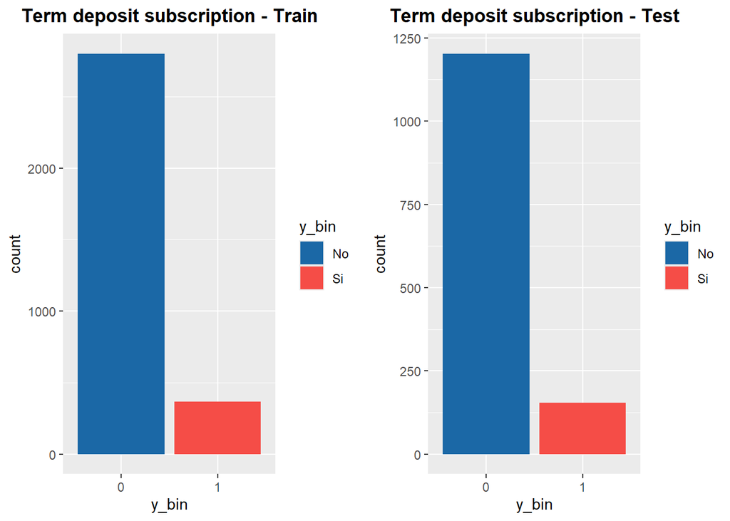

```r
par(mfrow=c(2,2))

# conteggio Training set
Count_Train <- ggplot(train.bank1, aes(x = y_bin, fill = y_bin)) +
  geom_bar() +
  scale_fill_manual(labels = c('No', 'Si'), values = c("#1B68A6", "#F54D47")) +
  theme(plot.title = element_text(face = 'bold', hjust = 0.5)) +
  ggtitle('Term deposit subscription - Train')

# conteggio Test set
Count_Test <- ggplot(test.bank1, aes(x = y_bin, fill = y_bin)) +
  geom_bar() +
  scale_fill_manual(labels = c('No', 'Si'), values = c("#1B68A6", "#F54D47")) +
  theme(plot.title = element_text(face = 'bold', hjust = 0.5)) +
  ggtitle('Term deposit subscription - Test')

plot_grid(Count_Train, Count_Test)
```

# Analisi di regressione logistica

Stimiamo il modello sul Training Set:

```r
reglog = glm(y_bin ~ age + balance + day + duration + campaign + pdays + previous
                ,family=binomial, data = train.bank1)

summary(reglog)
```

```
##
## Call:
## glm(formula = y_bin ~ age + balance + day + duration + campaign +
##     pdays + previous, family = binomial, data = train.bank1)
##
## Coefficients:
##                Estimate  Std. Error z value             Pr(>|z|)
## (Intercept) -3.58369482  0.29590330 -12.111 < 0.0000000000000002 ***
## age          0.00854109  0.00558534   1.529             0.126215
## balance      0.00003063  0.00001605   1.909             0.056246 .
## day          0.00565871  0.00776210   0.729             0.465991
## duration     0.00353973  0.00021324  16.600 < 0.0000000000000002 ***
## campaign    -0.13111481  0.03484476  -3.763             0.000168 ***
## pdays        0.00208488  0.00060582   3.441             0.000579 ***
## previous     0.09135035  0.03136919   2.912             0.003590 **
## ---
## Signif. codes:  0 '***' 0.001 '**' 0.01 '*' 0.05 '.' 0.1 ' ' 1
##
## (Dispersion parameter for binomial family taken to be 1)
##
##     Null deviance: 2266.8  on 3163  degrees of freedom
## Residual deviance: 1864.9  on 3156  degrees of freedom
## AIC: 1880.9
##
## Number of Fisher Scoring iterations: 6
```

```r
reglog1 = glm(y_bin ~ age  + duration + campaign + pdays + previous
                ,family=binomial, data = train.bank1)

summary(reglog1)
```

```
##
## Call:
## glm(formula = y_bin ~ age + duration + campaign + pdays + previous,
##     family = binomial, data = train.bank1)
##
## Coefficients:
##               Estimate Std. Error z value             Pr(>|z|)
## (Intercept) -3.4683009  0.2684773 -12.918 < 0.0000000000000002 ***
## age          0.0091803  0.0055714   1.648             0.099402 .
## duration     0.0035258  0.0002131  16.548 < 0.0000000000000002 ***
## campaign    -0.1294334  0.0346377  -3.737             0.000186 ***
## pdays        0.0020273  0.0006033   3.360             0.000779 ***
## previous     0.0919547  0.0313494   2.933             0.003355 **
## ---
## Signif. codes:  0 '***' 0.001 '**' 0.01 '*' 0.05 '.' 0.1 ' ' 1
##
## (Dispersion parameter for binomial family taken to be 1)
##
##     Null deviance: 2266.8  on 3163  degrees of freedom
## Residual deviance: 1868.7  on 3158  degrees of freedom
## AIC: 1880.7
##
## Number of Fisher Scoring iterations: 6
```

Il modello ridotto mantiene `age`, `duration`, `campaign`, `pdays` e `previous`, come nell’analisi originale. Le variabili escluse sono `balance` e `day`. Con uno split diverso, la significatività dei singoli coefficienti può cambiare: va verificata nel summary della nuova esecuzione. I coefficienti descrivono associazioni condizionate, non effetti causali.

Ora diamo un’occhiata al McFadden $R^{2}$:

Utilizziamo il pacchetto pscl:

```r
mcR = pR2(reglog1)[4]
```

```
## fitting null model for pseudo-r2
```

```r
mcR
```

```
##  McFadden
## 0.1756502
```

Il McFadden pseudo-$R^2$ è 0.1757. Misura il miglioramento della log-verosimiglianza rispetto al modello con sola intercetta e non è una quota di varianza spiegata come il $R^2$ OLS. La valutazione predittiva è svolta sul Test set.

Ora valutiamo la previsione del modello e costruiamo la Confusion-Matrix:

*Primo Metodo*

**Predizione per la confusion-matrix**

```r
# type='response' indica che si vogliono le probabilità predette
prevision <- predict(reglog1, newdata=test.bank1, type='response')

# digits=10 arrotonda le prob. predette alla decima cifra decimale
prob.pred <- round(prevision, digits = 10)

# creiamo un dataframe per valutare il modello di classificazione
dataframe_test <- cbind(test.bank1, "pr subscription" = prob.pred)
head(dataframe_test)
```

```
##    age balance day duration campaign pdays previous  y y_bin pr subscription
## 1   30    1787  19       79        1    -1        0 no     0      0.04539849
## 7   36     307  14      341        1   330        2 no     0      0.22934339
## 23  44     106  12      109        2    -1        0 no     0      0.05016597
## 25  26     543  30      169        3    -1        0 no     0      0.04634965
## 30  53     105  21       74        2    -1        0 no     0      0.04825813
## 32  31     171  27       81        3    -1        0 no     0      0.03596955
```

```r
# settiamo il boundary
prevision1 <- ifelse(prevision > 0.5,1,0)
prop.pred <- round(prevision1,digits =10)
dataframe_test <- cbind(test.bank1,"pr subscription"=prob.pred)
head(dataframe_test)
```

```
##    age balance day duration campaign pdays previous  y y_bin pr subscription
## 1   30    1787  19       79        1    -1        0 no     0      0.04539849
## 7   36     307  14      341        1   330        2 no     0      0.22934339
## 23  44     106  12      109        2    -1        0 no     0      0.05016597
## 25  26     543  30      169        3    -1        0 no     0      0.04634965
## 30  53     105  21       74        2    -1        0 no     0      0.04825813
## 32  31     171  27       81        3    -1        0 no     0      0.03596955
```

```r
summary(prevision1)
```

```
##    Min. 1st Qu.  Median    Mean 3rd Qu.    Max.
## 0.00000 0.00000 0.00000 0.04053 0.00000 1.00000
```

```r
# utilizzo il pacchetto caret per plottare la confusion matrix
cm <- confusionMatrix(
  factor(prevision1, levels = c(0, 1)),
  factor(test.bank1$y_bin, levels = c("0", "1")),
  positive = "1"
)
cm
```

```
## Confusion Matrix and Statistics
##
##           Reference
## Prediction    0    1
##          0 1178  124
##          1   24   31
##
##                Accuracy : 0.8909
##                  95% CI : (0.8731, 0.907)
##     No Information Rate : 0.8858
##     P-Value [Acc > NIR] : 0.2922
##
##                   Kappa : 0.2504
##
##  Mcnemar's Test P-Value : 0.0000000000000004027
##
##             Sensitivity : 0.20000
##             Specificity : 0.98003
##          Pos Pred Value : 0.56364
##          Neg Pred Value : 0.90476
##              Prevalence : 0.11422
##          Detection Rate : 0.02284
##    Detection Prevalence : 0.04053
##       Balanced Accuracy : 0.59002
##
##        'Positive' Class : 1
##
```

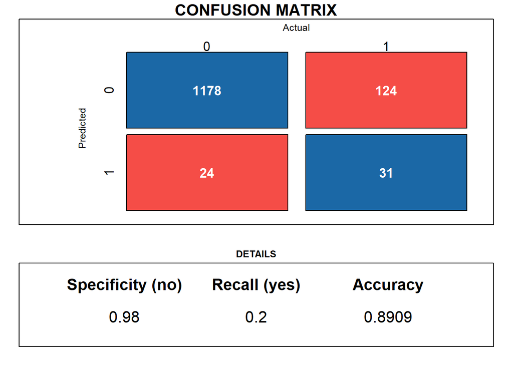

```r
# Funzione per disegnare la matrice di confusione
draw_confusion_matrix <- function(cm) {
  layout(matrix(c(1,1,2)))
  par(mar=c(2,2,2,2))
  plot(c(100, 345), c(300, 450), type = "n", xlab="", ylab="", xaxt='n', yaxt='n')
  title('CONFUSION MATRIX', cex.main=2)

  # creiamo la matrice
  rect(150, 430, 240, 370, col="#1B68A6")
  text(195, 435, '0', cex=1.6)
  rect(250, 430, 340, 370, col="#F54D47")
  text(295, 435, '1', cex=1.6)
  text(125, 370, 'Predicted', cex=1.2, srt=90, font=1)
  text(245, 450, 'Actual', cex=1.2, font=1)
  rect(150, 305, 240, 365, col="#F54D47")
  rect(250, 305, 340, 365, col="#1B68A6")
  text(140, 400, '0', cex=1.6, srt=90)
  text(140, 335, '1', cex=1.6, srt=90)

  # aggiungiamo cm nei risultati
  res <- as.numeric(cm$table)
  text(195, 400, res[1], cex=1.6, font=2, col='white')
  text(195, 335, res[2], cex=1.6, font=2, col='white')
  text(295, 400, res[3], cex=1.6, font=2, col='white')
  text(295, 335, res[4], cex=1.6, font=2, col='white')

  # aggiungiamo le specifiche
  plot(c(100, 0), c(100, 0), type = "n", xlab="", ylab="", main = "DETAILS", xaxt='n', yaxt='n')
  text(80, 75, names(cm$overall)[1], cex=2, font=2)
  text(80, 35, round(as.numeric(cm$overall[1]), 4), cex=2)
  text(50, 75, "Recall (yes)", cex=2, font=2)
  text(50, 35, round(as.numeric(cm$byClass["Sensitivity"]), 4), cex=2)
  text(20, 75, "Specificity (no)", cex=2, font=2)
  text(20, 35, round(as.numeric(cm$byClass["Specificity"]), 4), cex=2)
}

# Disegna la matrice di confusione
draw_confusion_matrix(cm)
```

La classe positiva è esplicitamente `1` (adesione al deposito).

- **Accuracy**: 89.09%.
- **Precisione della classe positiva**: 56.36%.
- **Sensibilità / recall della classe positiva**: 20%.
- **Specificità della classe negativa**: 98%.

Il dataset presenta classi sbilanciate: 521 adesioni su 4521 clienti. Per questo l’accuracy va confrontata con un classificatore che prevede sempre la classe maggioritaria. La soglia 0.5 è fissata a priori; una soglia alternativa richiederebbe una Validation separata e una valutazione dei costi degli errori.

```r
bank_metrics <- data.frame(
  accuracy = unname(cm$overall["Accuracy"]),
  majority_baseline_accuracy = max(table(test.bank1$y_bin)) / nrow(test.bank1),
  precision_yes = unname(cm$byClass["Pos Pred Value"]),
  recall_yes = unname(cm$byClass["Sensitivity"]),
  specificity_no = unname(cm$byClass["Specificity"])
)
bank_metrics
```

```
##    accuracy majority_baseline_accuracy precision_yes recall_yes specificity_no
## 1 0.8909359                  0.8857775     0.5636364        0.2      0.9800333
```

Il secondo metodo seguente usa le stesse previsioni e deve restituire la stessa accuracy, a meno dell’arrotondamento di visualizzazione.

*Secondo Metodo*

```r
fitted.results <- predict(reglog1 ,newdata= test.bank1 ,type='response')
fitted.results <- ifelse(fitted.results > 0.5,1,0)

misClasificError <- mean(fitted.results !=test.bank1$y_bin)
print(paste('Accuracy',1-misClasificError))
```

```
## [1] "Accuracy 0.890935887988209"
```

Ora calcoliamo ROC e AUC:

- la curva **ROC** è un grafico che illustra la capacità diagnostica di un modello di classificazione binaria tracciando il tasso di veri positivi (True Positive Rate, TPR) contro il tasso di falsi positivi (False Positive Rate, FPR) a vari valori di soglia;
- l’**AUC** è l’Area Under the Curve (AUC) misura la performance per i modelli di classificazione binaria ed esso varia tra 0 e 1.

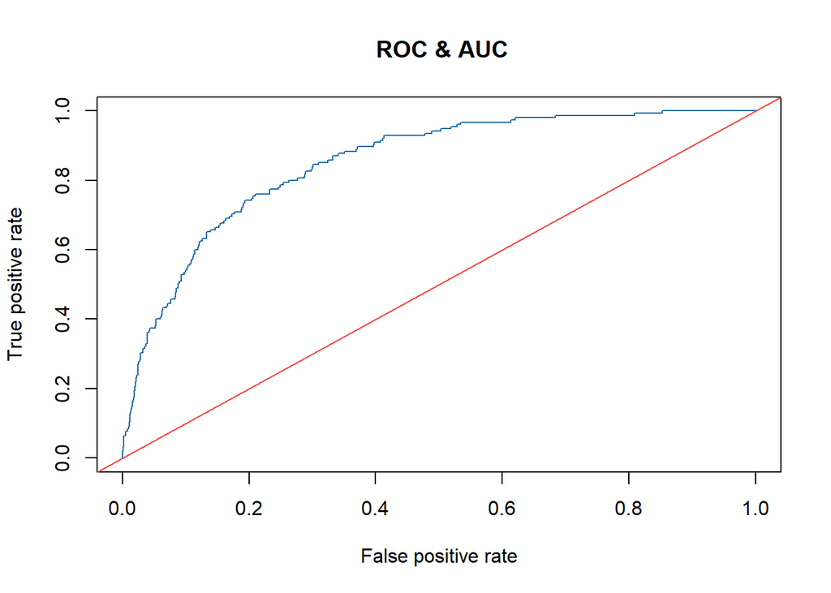

```r
# utilizziamo la librearia ROCR
p <- prevision1 <- predict(reglog1, newdata = test.bank1, type='response')

pr <- prediction(p, test.bank1$y_bin)
auc <- performance(pr, measure = "auc")
auc <- auc@y.values[[1]]
prf <- performance(pr, measure = "tpr", x.measure = "fpr")
plot(prf, col="#1B68A6" , main = ' ROC & AUC')
abline(0,1, col="#F54D47")
```

```r
print(paste0("AUC : ", round(auc, 4)))
```

```
## [1] "AUC : 0.8518"
```

L’AUC sul Test set è 0.8518. La curva ROC descrive il compromesso tra sensibilità e tasso di falsi positivi al variare della soglia; l’AUC valuta il ranking dei punteggi. Nessuna delle due misure garantisce buona calibrazione delle probabilità o recall elevata alla soglia 0.5.

# Conclusioni

**Regressione multipla.** Il modello ridotto associa i prezzi immobiliari a reddito medio dell’area, età dell’immobile, numero di stanze e popolazione dell’area. Il $R^2$ corretto sul Training set è 0.9175; RMSE e MAE sul Test set sono rispettivamente 98700.97 e 79196.78 dollari. I controlli diagnostici sono utili per esaminare residui e osservazioni influenti, ma non dimostrano tutte le assunzioni del modello. Le associazioni non hanno interpretazione causale.

**Regressione logistica.** Il modello di adesione al deposito viene valutato con matrice di confusione, precisione, recall, specificità e ROC-AUC. L’AUC è 0.8518; l’accuracy è 89.09%, contro 88.58% del riferimento maggioritario nel Test set. In presenza di sbilanciamento, l’accuracy da sola non descrive il riconoscimento delle adesioni.

L’inclusione di `duration` limita il modello alla valutazione dopo il contatto. Per un uso prima della chiamata, il passo successivo è stimare un modello senza tale variabile e validare soglia, calibrazione e stabilità su nuovi campioni. La fonte primaria dei dati immobiliari e la provenienza esatta dei file didattici non sono documentate nei materiali ricevuti.

[^1]: Il leverage è una misura che indica quanto una singola osservazione (un punto di dati) è distante dalla media delle variabili indipendenti. In un modello di regressione, il leverage aiuta a identificare punti che hanno un’influenza sproporzionata sul modello.